# Predicción salarios NBA

Predicción salarios NBA Ignacio Ruiz de Zuazu Echevarría 28/10/2020

[link a GitHub](https://github.com/ignacio-ruiz-de-zuazu/Prediccion-practicas.git)

[figure not shown]

## Objetivo del trabajo

El objetivo de este trabajo es el de encontrar un modelo capaz de predecir el salario de un jugador de la NBA a partir de una serie de variables que vendrán definidas en el dataset de la NBA. A partir de modelos de regresión lineal encontraremos las variables más relevantes que definen el salario de un jugador a la hora de realizar una predicción con el menor error posible. En este trabajo se han realizado 4 modelos, cada uno con criterios distintos con el fin de encontrar el modelo más eficiente y exlpicativo.

### Librerías que se han empleado en el trabajo

```r
library(readr)
library(tidyr)
library(ggplot2)
library(tidyverse)
library(corrplot)
library(car)
library(MASS)
library(dplyr)
library(readr)
```

```r
nba <- read_csv("data/nba.csv")
nba
```

```
## # A tibble: 485 x 28
##    Player Salary NBA_Country NBA_DraftNumber   Age Tm        G    MP   PER `TS%`
##    <chr>   <dbl> <chr>                 <dbl> <dbl> <chr> <dbl> <dbl> <dbl> <dbl>
##  1 Zhou ~ 8.16e5 China                    43    22 HOU      16    87   0.6 0.303
##  2 Zaza ~ 3.48e6 Georgia                  42    33 GSW      66   937  16.8 0.608
##  3 Zach ~ 1.23e7 USA                      19    36 SAC      59  1508  17.3 0.529
##  4 Zach ~ 3.20e6 USA                      13    22 CHI      24   656  14.6 0.499
##  5 Zach ~ 3.06e6 USA                      10    20 POR      62   979   8.2 0.487
##  6 Yogi ~ 1.31e6 USA                      62    24 DAL      79  2238  11.5 0.543
##  7 Xavie~ 7.42e4 USA                      62    30 BOS       2     7  -4.9 0
##  8 Xavie~ 4.61e4 Canada                   62    23 MEM       5   118   0.9 0.315
##  9 Wilso~ 1.20e7 USA                      23    30 DEN      70  2200  11.1 0.543
## 10 Willy~ 1.44e6 Spain                    35    23 TOT      45   430  20.6 0.592
## # ... with 475 more rows, and 18 more variables: `3PAr` <dbl>, FTr <dbl>,
## #   `ORB%` <dbl>, `DRB%` <dbl>, `TRB%` <dbl>, `AST%` <dbl>, `STL%` <dbl>,
## #   `BLK%` <dbl>, `TOV%` <dbl>, `USG%` <dbl>, OWS <dbl>, DWS <dbl>, WS <dbl>,
## #   `WS/48` <dbl>, OBPM <dbl>, DBPM <dbl>, BPM <dbl>, VORP <dbl>
```

```r
dim(nba)
```

```
## [1] 485  28
```

## Modelo de regresión 1 Con todas las varaibles

En primer lugar realizaremos un modelo de regresión con todas las variables del dataset. Para ello en primer lugar quitaremos todos aquellos jugadores que puedan estar repetidos en el data set, que en este caso son dos con valores NaN.

```r
nba_con_jugadores <- nba %>% distinct(Player, .keep_all = TRUE)
```

En segundo lugar, seleccionamos las variables que sean relevantes para la fabricación de nuestro modelo.

```r
nba_sin_categoricas <- nba_con_jugadores %>% dplyr::select(Salary,Age,NBA_DraftNumber,
                                                    G:VORP)
```

Con estos datos obtendremos nuestra regresión definida como `regresion1`.

```r
regresion1 <- lm(Salary~., data = nba_sin_categoricas)
summary(regresion1)
```

```
##
## Call:
## lm(formula = Salary ~ ., data = nba_sin_categoricas)
##
## Residuals:
##       Min        1Q    Median        3Q       Max
## -15354874  -3000738   -385019   2114291  21684587
##
## Coefficients:
##                 Estimate Std. Error t value Pr(>|t|)
## (Intercept)     -2257549    4909948  -0.460    0.646
## Age               517569      56727   9.124  < 2e-16 ***
## NBA_DraftNumber   -60665      12807  -4.737 2.90e-06 ***
## G                -154422      25036  -6.168 1.53e-09 ***
## MP                  5670       1087   5.217 2.76e-07 ***
## PER              -353478     281293  -1.257    0.210
## `TS%`           -2184162    5160879  -0.423    0.672
## `3PAr`          -3441403    2364332  -1.456    0.146
## FTr              -151800     889330  -0.171    0.865
## `ORB%`          -1067597     906856  -1.177    0.240
## `DRB%`           -868491     897793  -0.967    0.334
## `TRB%`           2033598    1797209   1.132    0.258
## `AST%`            -19939      47665  -0.418    0.676
## `STL%`           -194112     423061  -0.459    0.647
## `BLK%`            110027     318948   0.345    0.730
## `TOV%`              4106      52808   0.078    0.938
## `USG%`            167442     105277   1.590    0.112
## OWS             -1323605    4518535  -0.293    0.770
## DWS             -1790690    4544903  -0.394    0.694
## WS               1877630    4523606   0.415    0.678
## `WS/48`          1893689   11822704   0.160    0.873
## OBPM             1935687    4772501   0.406    0.685
## DBPM             1494922    4687825   0.319    0.750
## BPM             -1353095    4705755  -0.288    0.774
## VORP              632085     635260   0.995    0.320
## ---
## Signif. codes:  0 '***' 0.001 '**' 0.01 '*' 0.05 '.' 0.1 ' ' 1
##
## Residual standard error: 5114000 on 456 degrees of freedom
##   (2 observations deleted due to missingness)
## Multiple R-squared:  0.5469, Adjusted R-squared:  0.5231
## F-statistic: 22.94 on 24 and 456 DF,  p-value: < 2.2e-16
```

### Estudio de la regresión. Normalidad.

El `qqplot`nos muestra que hay datos que existen cuantiles que no siguen una msima distribución.

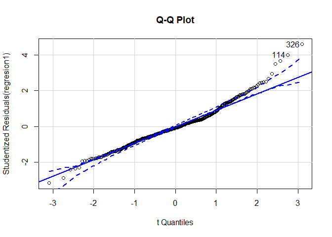

```
## [1] 114 326
```

```r
qqPlot(regresion1, labels = row.names(nba), id.method = "identify",
       simulate = TRUE, main = "Q-Q Plot")
```

### Estudio de la regresión. Análisis del error.

Histograma + densidad + normal + rug

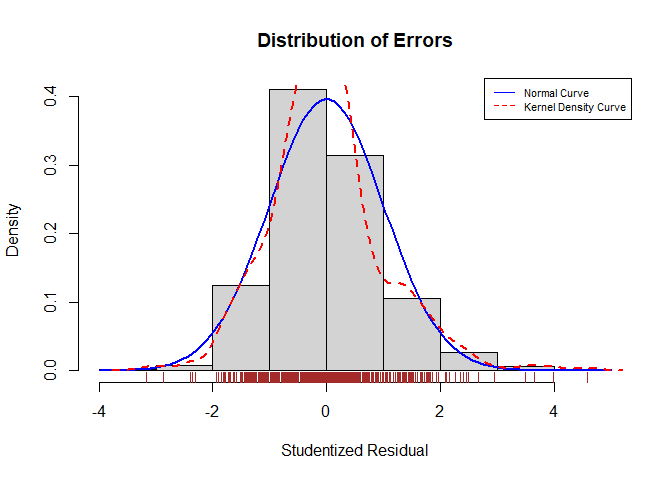

```r
residplot <- function(fit, nbreaks=10) {
  z <- rstudent(fit)
  hist(z, breaks = nbreaks, freq = FALSE,
       xlab = "Studentized Residual",
       main = "Distribution of Errors")
  rug(jitter(z), col = "brown")
  curve(dnorm(x, mean = mean(z), sd = sd(z)),
        add = TRUE, col = "blue", lwd = 2)
  lines(density(z)$x, density(z)$y,
        col = "red", lwd = 2, lty = 2)
  legend("topright",
         legend = c( "Normal Curve", "Kernel Density Curve"),
         lty = 1:2, col = c("blue","red"), cex = .7)}

residplot(regresion1)
```

Vemos que los valores del error en la regresión se concentran en gran medidaentre los valores -1 y 1 con valores extremos en +2 llegando hasta +4.

### Estudio de la regresión. Test de Shapiro-Wilk

```r
vResid <- resid(regresion1)
shapiro.test(vResid)
```

```
##
##  Shapiro-Wilk normality test
##
## data:  vResid
## W = 0.9709, p-value = 3.509e-08
```

Rechazamos la hipotesis nula puesto que tiene un p-valor inferior al nivel de significación y por lo tanto se concluye que los errores no han sido generados por una distribución normal.

### Estudio de la regresión. Multicolinealidad

```r
vif(regresion1)
```

```
##             Age NBA_DraftNumber               G              MP             PER
##        1.078945        1.340171        6.999197       14.172245      110.918970
##           `TS%`          `3PAr`             FTr          `ORB%`          `DRB%`
##        6.146914        5.301979        1.264400      317.236811      684.388198
##          `TRB%`          `AST%`          `STL%`          `BLK%`          `TOV%`
##     1439.666086        3.445392        3.208627        5.305430        1.917592
##          `USG%`             OWS             DWS              WS         `WS/48`
##        6.861721     1329.661494      405.100887     2683.730741       67.930181
##            OBPM            DBPM             BPM            VORP
##    10524.307876     2307.119717    12928.849699       11.551583
```

```r
sqrt(vif(regresion1)) > 2
```

```
##             Age NBA_DraftNumber               G              MP             PER
##           FALSE           FALSE            TRUE            TRUE            TRUE
##           `TS%`          `3PAr`             FTr          `ORB%`          `DRB%`
##            TRUE            TRUE           FALSE            TRUE            TRUE
##          `TRB%`          `AST%`          `STL%`          `BLK%`          `TOV%`
##            TRUE           FALSE           FALSE            TRUE           FALSE
##          `USG%`             OWS             DWS              WS         `WS/48`
##            TRUE            TRUE            TRUE            TRUE            TRUE
##            OBPM            DBPM             BPM            VORP
##            TRUE            TRUE            TRUE            TRUE
```

Observamos que la mayoría de las variables dan problemas de multicolinealidad, posiblemente a que muchas de las estadísticas tienen que ver con cada partido que se juega y hay estadísticas que tienen que ver unas con otras como ocurre en el caso de los rebotes totales y los rebotes ofensivos.

### Estudio de la regesión. Outliers

Valores atípicos

```r
outlierTest(regresion1)
```

```
##     rstudent unadjusted p-value Bonferroni p
## 326 4.586546         5.8334e-06    0.0028059
## 114 3.992498         7.6212e-05    0.0366580
```

Existen dos valores atipicos

Valores extremos

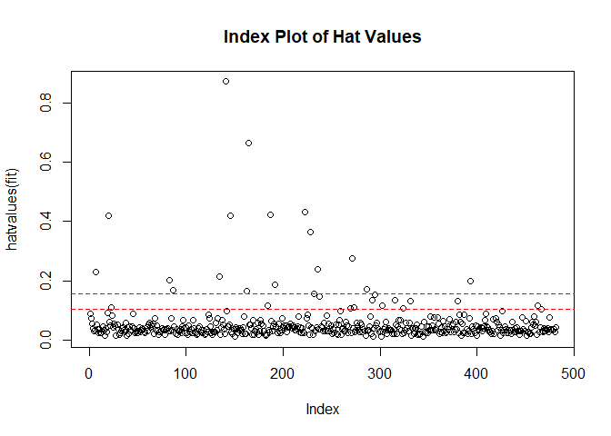

```
## integer(0)
```

```r
hat.plot <- function(fit) {
  p <- length(coefficients(fit))
  n <- length(fitted(fit))
  plot(hatvalues(fit), main = "Index Plot of Hat Values")
  abline(h = c(2,3)*p/n, col = "red", lty = 2)
  identify(1:n, hatvalues(fit), names(hatvalues(fit)))
}
hat.plot(regresion1)
```

Los valores extremos son: 20, 141, 146, 164, 187, 223, 228

Valores influyentes. Cooks Distance D

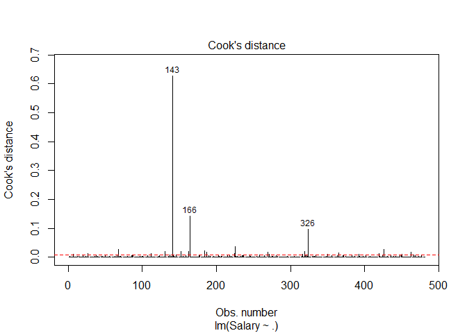

```r
cutoff <- 4/(nrow(nba_sin_categoricas) - length(regresion1$coefficients) - 2)
plot(regresion1, which = 4, cook.levels = cutoff)
abline(h = cutoff, lty = 2, col = "red")
```

Los valroes influyentes son: 143, 166, 326

Influence Plot

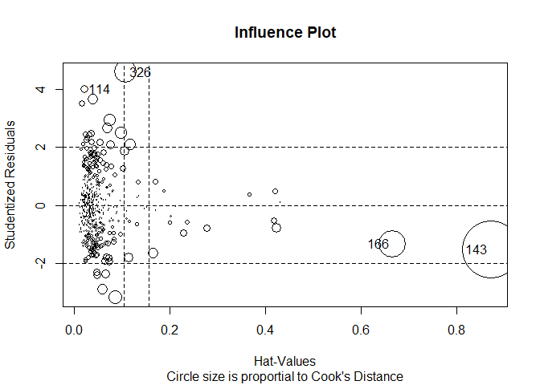

```
##       StudRes        Hat      CookD
## 114  3.992498 0.02090529 0.01318196
## 143 -1.521426 0.87164596 0.62696299
## 166 -1.334465 0.66613625 0.14188127
## 326  4.586546 0.10778962 0.09737912
```

```r
influencePlot(regresion1, id.method = "identify", main = "Influence Plot",
              sub = "Circle size is proportial to Cook's Distance" )
```

Outliers totales : 20, 114, 141, 143, 146, 164, 166, 187, 223, 228, 326

## Modelo de predicción 1

Una vez estudiado el modelo de regresión se procede a realizar el modelo de predicción a partir de una muestra aleatoria `set.seed()` del conjunto de datos que hemos empleado en la regresión en n=10 de tal forma que:

```r
set.seed(1234)
n <- 10
muestra <- sample(1:nrow(nba_sin_categoricas), size = n, replace = FALSE)
datos_de_la_muestra <- nba_sin_categoricas[muestra,]
datos_de_la_muestra
```

```
## # A tibble: 10 x 25
##    Salary   Age NBA_DraftNumber     G    MP   PER `TS%` `3PAr`   FTr `ORB%`
##     <dbl> <dbl>           <dbl> <dbl> <dbl> <dbl> <dbl>  <dbl> <dbl>  <dbl>
##  1 5.22e6    31              20    31   276   8.2 0.444  0.277 0.17     7.4
##  2 2.55e6    23              19    65  2265  16.6 0.599  0.436 0.175    1.8
##  3 5.56e6    21               2    44  1124  15.5 0.506  0.398 0.209    2.7
##  4 1.47e6    24              37    44   668  16.8 0.566  0.144 0.236    8.6
##  5 3.85e6    29              26    23   196   4   0.398  0.449 0.347    4.2
##  6 1.31e6    25              42    74  1067  14.2 0.587  0.691 0.136    1.9
##  7 1.47e6    22              41    71  2288  24.4 0.607  0.279 0.317    9.2
##  8 2.46e7    32               4    55  1753  24.3 0.601  0.475 0.288    2.3
##  9 2.42e6    23              12    74  2229  16.1 0.587  0.447 0.239    7.5
## 10 1.58e6    29              53    55   711   6.2 0.485  0.52  0.049    1.2
## # ... with 15 more variables: `DRB%` <dbl>, `TRB%` <dbl>, `AST%` <dbl>,
## #   `STL%` <dbl>, `BLK%` <dbl>, `TOV%` <dbl>, `USG%` <dbl>, OWS <dbl>,
## #   DWS <dbl>, WS <dbl>, `WS/48` <dbl>, OBPM <dbl>, DBPM <dbl>, BPM <dbl>,
## #   VORP <dbl>
```

```r
prediccion_de_la_muestra <- predict(regresion1, datos_de_la_muestra, se.fit = TRUE)
prediccion_de_la_muestra
```

```
## $fit
##        1        2        3        4        5        6        7        8
##  6679178 11160824  6817193  4619128  4143566  1078683 15613034 20081873
##        9       10
## 12042484  1045636
##
## $se.fit
##         1         2         3         4         5         6         7         8
##  845126.2 1015965.1 1072824.5  773143.1  823350.3  873910.2 1242434.8 1273021.0
##         9        10
##  771113.5  780379.8
##
## $df
## [1] 456
##
## $residual.scale
## [1] 5114102
```

Como vimos anteriormente, el error residual del modelo de regresión es muy elvado por lo que se pierde precisión a la hora de realizar las predicciones y por lo que se observa en los resultados obtenidos, difieren mucho de la realidad y también podemos ver que según su `se.fit`que las desviacions tipicas son elevadas.

# Modelo 2 de predicción mediante selección de variables

Para este caso realizaremos un modelo de predicción siguiendo la selección de variables siguiendo el criterio de información de Akaike (AIC). Dentro de este criterio se empleará el método: Both forward Stepwise and Backward Stepwise `AIC1 <- stepAIC(regresion1, direction = "both")`

```r
regresion2 <- lm(formula = Salary ~ Age + NBA_DraftNumber + G + MP + PER +
     `3PAr` + `ORB%` + `TRB%` + `USG%` + WS + OBPM, data = nba_sin_categoricas)
```

Obtenemos que las variables relevantes para definir el salario de un jugador son: * Edad * Número en el draft * Partidos * Minutos totales jugados * PER * Intentos de 3 * Rebote ofensivo * Rebote total * posesion del balon * Victorias en las que contribuye * Victorias gracias a su ofensiva

```r
summary(regresion2)
```

```
##
## Call:
## lm(formula = Salary ~ Age + NBA_DraftNumber + G + MP + PER +
##     `3PAr` + `ORB%` + `TRB%` + `USG%` + WS + OBPM, data = nba_sin_categoricas)
##
## Residuals:
##       Min        1Q    Median        3Q       Max
## -15536716  -3013948   -399057   2312435  21613763
##
## Coefficients:
##                   Estimate Std. Error t value Pr(>|t|)
## (Intercept)     -3902834.8  2792184.5  -1.398  0.16284
## Age               512110.7    55165.6   9.283  < 2e-16 ***
## NBA_DraftNumber   -62286.8    12313.0  -5.059 6.07e-07 ***
## G                -159302.2    21684.1  -7.347 9.09e-13 ***
## MP                  5209.8      851.3   6.120 1.98e-09 ***
## PER              -319811.7   142417.6  -2.246  0.02520 *
## `3PAr`          -2999678.8  1691945.1  -1.773  0.07689 .
## `ORB%`           -200783.6    92677.1  -2.166  0.03078 *
## `TRB%`            333616.3   103586.8   3.221  0.00137 **
## `USG%`            129831.3    56764.1   2.287  0.02263 *
## WS                844837.0   163046.2   5.182 3.27e-07 ***
## OBPM              549745.2   242220.2   2.270  0.02368 *
## ---
## Signif. codes:  0 '***' 0.001 '**' 0.01 '*' 0.05 '.' 0.1 ' ' 1
##
## Residual standard error: 5067000 on 469 degrees of freedom
##   (2 observations deleted due to missingness)
## Multiple R-squared:  0.5425, Adjusted R-squared:  0.5318
## F-statistic: 50.57 on 11 and 469 DF,  p-value: < 2.2e-16
```

Vemos que con respecto al modelo anterior se ha mejorado tanto el error de los residuos hasta llegar cerca a los 5 millones y con un R^2 ajustado del 53%. Generamos una tabla de datos con las variables relevantes según el nuevo criterio

```r
nba_sin_categoricas2 <- nba_sin_categoricas %>% dplyr::select(Salary, Age, NBA_DraftNumber, G,
                                                              MP, PER, `3PAr`,
                                                              `ORB%`, `TRB%`,
                                                              `USG%`, WS, OBPM)
```

## Modelo de predicción 2

Elaboramos el nuevo modelo modelo de predicción siguiendo el criterio del modelo de predicción 1 con la nueva tabla de datos.

```r
set.seed(1234)
n <- 10
muestra <- sample(1:nrow(nba_sin_categoricas2), size = n, replace = FALSE)
datos_de_la_muestra <- nba_sin_categoricas2[muestra,]
datos_de_la_muestra
```

```
## # A tibble: 10 x 12
##    Salary   Age NBA_DraftNumber     G    MP   PER `3PAr` `ORB%` `TRB%` `USG%`
##     <dbl> <dbl>           <dbl> <dbl> <dbl> <dbl>  <dbl>  <dbl>  <dbl>  <dbl>
##  1 5.22e6    31              20    31   276   8.2  0.277    7.4   10.7   21.9
##  2 2.55e6    23              19    65  2265  16.6  0.436    1.8    4.3   20.6
##  3 5.56e6    21               2    44  1124  15.5  0.398    2.7    8.4   30.7
##  4 1.47e6    24              37    44   668  16.8  0.144    8.6   15.5   16.7
##  5 3.85e6    29              26    23   196   4    0.449    4.2    7.4   15
##  6 1.31e6    25              42    74  1067  14.2  0.691    1.9    7.8   17.4
##  7 1.47e6    22              41    71  2288  24.4  0.279    9.2   18.4   24.1
##  8 2.46e7    32               4    55  1753  24.3  0.475    2.3    9.7   24.3
##  9 2.42e6    23              12    74  2229  16.1  0.447    7.5   12.3   20.9
## 10 1.58e6    29              53    55   711   6.2  0.52     1.2    6.1    7.8
## # ... with 2 more variables: WS <dbl>, OBPM <dbl>
```

```r
prediccion_de_la_muestra2 <- predict(regresion2, datos_de_la_muestra, se.fit = TRUE)
prediccion_de_la_muestra2
```

```
## $fit
##          1          2          3          4          5          6          7
##  5812043.7 11205194.1  6446277.3  4114492.8  4110509.4  1253707.1 15201985.8
##          8          9         10
## 20748503.2 12199777.0   601566.5
##
## $se.fit
##        1        2        3        4        5        6        7        8
## 593563.9 638935.4 883326.3 482357.3 502544.5 783467.0 969787.0 966993.9
##        9       10
## 601825.4 606549.8
##
## $df
## [1] 469
##
## $residual.scale
## [1] 5067174
```

Las conclusiones se asemejan a las del modelo anterior. En este modelo destacamos la disminución en el error.

# Modelo 3 de predicción mediante eliminacion de outliers

Se realiza un modelo con las varaibles empleadas en el modelo 2 con la diferencia de que en este modelo se eliminarán todos los outliers.

En primer lugar se van a identificar los outliers.

### Valores atípicos

```r
outlierTest(regresion2)
```

```
##     rstudent unadjusted p-value Bonferroni p
## 326 4.418019         1.2388e-05    0.0059588
## 114 4.097004         4.9325e-05    0.0237250
```

Encontramos dos valores atípicos

### Valores Extremos

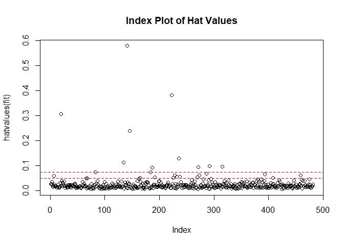

```
## integer(0)
```

```r
hat.plot <- function(fit) {
  p <- length(coefficients(fit))
  n <- length(fitted(fit))
  plot(hatvalues(fit), main = "Index Plot of Hat Values")
  abline(h = c(2,3)*p/n, col = "red", lty = 2)
  identify(1:n, hatvalues(fit), names(hatvalues(fit)))
}
hat.plot(regresion2)
```

Los valores extremos son: 20 141 146 223

### Valores influyentes. Cooks Distance D

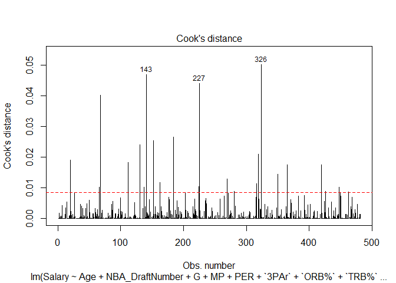

```r
cutoff <- 4/(nrow(nba_sin_categoricas2) - length(regresion2$coefficients) - 2)
plot(regresion2, which = 4, cook.levels = cutoff)
abline(h = cutoff, lty = 2, col = "red")
```

Valores influyentes: 143, 227, 326

Influence Plot

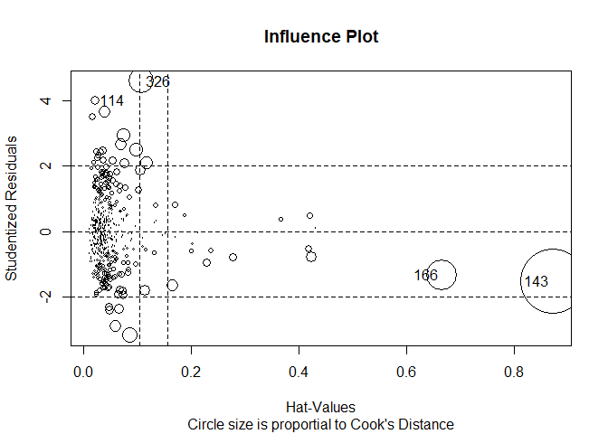

```
##       StudRes        Hat      CookD
## 114  3.992498 0.02090529 0.01318196
## 143 -1.521426 0.87164596 0.62696299
## 166 -1.334465 0.66613625 0.14188127
## 326  4.586546 0.10778962 0.09737912
```

```r
influencePlot(regresion1, id.method = "identify", main = "Influence Plot",
              sub = "Circle size is proportial to Cook's Distance" )
```

114, 326, 166, 143

Outliers totales : 20, 114, 141,143, 227, 146, 166, 223, 326

La nueva tabla de datos será:

```r
nba_sin_categoricas2 <- nba_sin_categoricas2[c(-20, -114, -141, -143, -227, -146,
                                               -166, -223, -326),]
```

Con esta tabla de datos y con la regresión 2 calculado en el anterior modelo construiremos el nuevo modelo de predicción sobre la muestra.

## Modelo de predicción 3

```r
set.seed(1234)
n <- 10
muestra <- sample(1:nrow(nba_sin_categoricas2), size = n, replace = FALSE)
datos_de_la_muestra <- nba_sin_categoricas2[muestra,]
datos_de_la_muestra
```

```
## # A tibble: 10 x 12
##    Salary   Age NBA_DraftNumber     G    MP   PER `3PAr` `ORB%` `TRB%` `USG%`
##     <dbl> <dbl>           <dbl> <dbl> <dbl> <dbl>  <dbl>  <dbl>  <dbl>  <dbl>
##  1 5.00e4    25              62     3    18   7.5  1        0      6     21.1
##  2 8.45e6    28              55    78  2468  11.9  0.364    2.5    5.1   16.2
##  3 7.84e6    25              62    51   856  12.3  0.005    8.8   12.6   13.4
##  4 2.50e6    37              13    20   163   6.3  0.259    1.4    5.9    9.3
##  5 1.71e6    27              37    66  1270   7.5  0.797    3.1   10.1   14.3
##  6 2.30e6    30              33    70  1499   9.7  0.474    5.1    9.9   11.5
##  7 9.22e4    23              62     6    60   2.4  0.611    1.8    4.7   15.7
##  8 1.47e6    20              26    24   165   7.1  0.148   10.1   15.2   19.6
##  9 2.12e6    38              62    19   152   4.9  0.462    3.8    6     13.4
## 10 1.00e7    30              21    65  1929  18.9  0.327    2.1    4.9   17.4
## # ... with 2 more variables: WS <dbl>, OBPM <dbl>
```

```r
prediccion_de_la_muestra2 <- predict(regresion2, datos_de_la_muestra, se.fit = TRUE)
prediccion_de_la_muestra2
```

```
## $fit
##          1          2          3          4          5          6          7
##  1632988.3  9417513.2  1688367.2  9997075.5  2668914.4  6345202.4   547850.8
##          8          9         10
##  1495868.3  7037878.5 14220792.5
##
## $se.fit
##         1         2         3         4         5         6         7         8
## 1018558.1  781979.2  686360.1  939096.4  725651.0  503558.9  666054.9  721213.3
##         9        10
##  827725.9  766796.3
##
## $df
## [1] 469
##
## $residual.scale
## [1] 5067174
```

# Modelo 4 de predicción mediante la eliminación de información irrelevante del dataset.

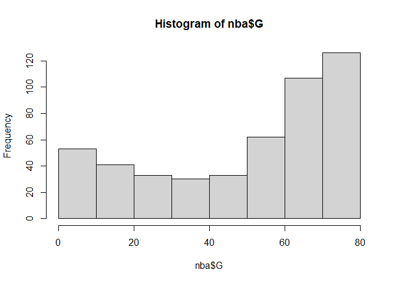

```r
hist(nba$G)
```

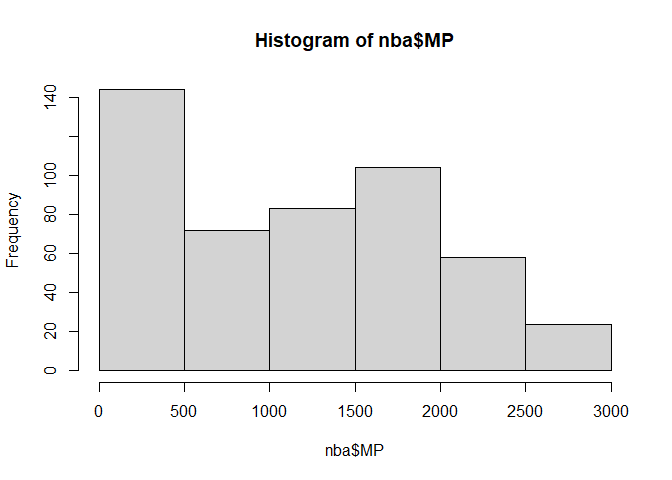

```r
hist(nba$MP)
```

Vemos que hay una gran cantidad de jugadores en la NBA que juegan un número escaso de partidos y también un número escaso de minutos. Por estas estadísticas, estos jugadores reciben un salario por lo que se parte de la hipotesis de que el salario no puede depender de estos datos.

Elaboramos la nueva tabla de datos.

```r
nba_sin_categoricas <- nba_con_jugadores %>% filter(G > 50 | MP > 2000 ) %>% dplyr::select(Salary,Age,NBA_DraftNumber, G:VORP)
```

Y elaboramos la nueva regresión.

```r
regresion3 <- lm(Salary~., data = nba_sin_categoricas)
```

Escojemos de nuevo el criterio de información de Akaike para encontrar las variables relevantes para el modelo. `stepAIC(regresion3, direction = "both")`

```r
regresion3 <- lm(formula = Salary ~ Age + NBA_DraftNumber + G + MP + `TS%` +
                   `3PAr` + FTr + `AST%` + `STL%` + `TOV%` + OWS + `WS/48` +
                   OBPM + BPM + VORP, data = nba_sin_categoricas)
```

Realizamos la búsqueda de los outliers en este modelo y encontramos los siguientes valores:

Outliers totales : 42 55 78 114 116 141 143 166 174 193 209 215 326

Se crea una tabla con los outliers eliminados.

```r
nba_sin_categoricas3 <- nba_sin_categoricas[c(-42,-55,-78,-114, -116, -141, -143,
                                              -166, -174,-193,-209,-215,-326),]
```

Y obtenemos nuestra regresión final

```r
regresion3 <- lm(formula = Salary ~ Age + NBA_DraftNumber + G + MP + `TS%` +
                   `3PAr` + FTr + `AST%` + `STL%` + `TOV%` + OBPM + BPM + VORP,
                 data = nba_sin_categoricas3)


summary(regresion3)
```

```
##
## Call:
## lm(formula = Salary ~ Age + NBA_DraftNumber + G + MP + `TS%` +
##     `3PAr` + FTr + `AST%` + `STL%` + `TOV%` + OBPM + BPM + VORP,
##     data = nba_sin_categoricas3)
##
## Residuals:
##       Min        1Q    Median        3Q       Max
## -14412270  -2869951   -244175   2737396  13018917
##
## Coefficients:
##                   Estimate Std. Error t value Pr(>|t|)
## (Intercept)      1.287e+07  8.795e+06   1.463 0.144546
## Age              6.604e+05  7.104e+04   9.296  < 2e-16 ***
## NBA_DraftNumber -5.382e+04  1.680e+04  -3.204 0.001519 **
## G               -1.664e+05  4.695e+04  -3.544 0.000464 ***
## MP               5.202e+03  9.136e+02   5.693 3.25e-08 ***
## `TS%`           -3.553e+07  1.414e+07  -2.512 0.012590 *
## `3PAr`          -3.505e+06  2.145e+06  -1.634 0.103333
## FTr              6.509e+06  3.591e+06   1.812 0.071043 .
## `AST%`          -2.137e+05  7.623e+04  -2.803 0.005435 **
## `STL%`          -1.486e+06  6.122e+05  -2.428 0.015828 *
## `TOV%`           2.540e+05  1.511e+05   1.681 0.093941 .
## OBPM             1.197e+06  4.995e+05   2.397 0.017225 *
## BPM             -1.090e+06  4.302e+05  -2.534 0.011858 *
## VORP             3.483e+06  8.184e+05   4.256 2.88e-05 ***
## ---
## Signif. codes:  0 '***' 0.001 '**' 0.01 '*' 0.05 '.' 0.1 ' ' 1
##
## Residual standard error: 4879000 on 269 degrees of freedom
## Multiple R-squared:  0.5943, Adjusted R-squared:  0.5746
## F-statistic: 30.31 on 13 and 269 DF,  p-value: < 2.2e-16
```

## Modelo de predicción 4

```r
set.seed(1234)
n <- 10
muestra <- sample(1:nrow(nba_sin_categoricas3), size = n, replace = FALSE)
datos_de_la_muestra <- nba_sin_categoricas3[muestra,]
datos_de_la_muestra
```

```
## # A tibble: 10 x 25
##    Salary   Age NBA_DraftNumber     G    MP   PER `TS%` `3PAr`   FTr `ORB%`
##     <dbl> <dbl>           <dbl> <dbl> <dbl> <dbl> <dbl>  <dbl> <dbl>  <dbl>
##  1 5.00e6    28              14    52  1398  14.8 0.547  0.385 0.255    3.4
##  2 6.29e6    20               2    52  1780  12.5 0.444  0.523 0.126    4.2
##  3 1.20e7    27               9    77  2663  20.7 0.571  0.441 0.307    1.2
##  4 4.08e6    22               5    71  1544  13.6 0.544  0.437 0.162    2.7
##  5 1.28e7    33              57    78  1967  14.9 0.55   0     0.299    9.8
##  6 5.00e6    39               9    77  1900  16.7 0.575  0.445 0.142    1.3
##  7 2.70e6    26              11    52   835  10.9 0.446  0.258 0.389    4.7
##  8 1.23e7    27              16    54  1619  19.7 0.536  0.25  0.115    6.6
##  9 3.29e6    32              62    75  1624  13.5 0.652  0.777 0.278    3.1
## 10 2.31e7    25               7    75  2561  16   0.542  0.272 0.262    3.2
## # ... with 15 more variables: `DRB%` <dbl>, `TRB%` <dbl>, `AST%` <dbl>,
## #   `STL%` <dbl>, `BLK%` <dbl>, `TOV%` <dbl>, `USG%` <dbl>, OWS <dbl>,
## #   DWS <dbl>, WS <dbl>, `WS/48` <dbl>, OBPM <dbl>, DBPM <dbl>, BPM <dbl>,
## #   VORP <dbl>
```

```r
prediccion_de_la_muestra3 <- predict(regresion3, datos_de_la_muestra, se.fit = TRUE)
prediccion_de_la_muestra3
```

```
## $fit
##        1        2        3        4        5        6        7        8
##  9988059  7618594 20479495  1916602 12833497 15674144  5697736 10921727
##        9       10
##  7715508 11389195
##
## $se.fit
##         1         2         3         4         5         6         7         8
##  877333.6 1544017.9 1068065.2  853571.9 1158071.6 1363782.1 1316323.0 1131148.0
##         9        10
## 1218564.3  938170.1
##
## $df
## [1] 269
##
## $residual.scale
## [1] 4879357
```

Es el modelo con menos error de todos, sin embargo sigue estando lejos del salario real de cada jugador de la NBA

# Conclusiones

Tras realizar este trabajo, se llega a la conclusión de que los distintos modelos elaborados para predecir el salario de un jugador se alejan de la realidad. Esto se puede deber a varios motivos. El primer motivo podría ser el que se ha llevado a cabo en el último modelo en el que muchos de los jugadores juegan pocos partidos y reciben un salario. El segundo motivo se puede deber a que pueden faltar variables que podrían ser relevantes en este estudio como los campeonatos ganados, títulos individuales ganados y la posición en la que juegan los jugadores (como variable categórica) ya que en las últimas temporadas NBA la posición de base resulta más relevante que la de un pívot. Es por este motivo que se podría realizar un clúster por jugadores por atributos y posiciones para conseguir un modelo relevante.